# Question 1: Supervised Learning for Bioprinting

In this question, we continue creating machine learning algorithms which can predict cell viability from bioprinting parameters, similar to Shuyu Tian et al. “Machine assisted experimentation of extrusion-based bioprinting systems”. In: *Micromachines* 12.7 (2021), p. 780. However, this time we are using neural networks.

You will train in PyTorch:

• a classification neural network to predict acceptable/unacceptable cell viability,

• a regression neural network to predict real-valued cell viability.

Preprocess the dataset according to the provided code in this thesis. https://scholarscompass.vcu.edu/cgi/viewcontent.cgi?article=7979&context=etd

For classification, do not use the “Acceptable Viability?” column. Instead, label a sample as acceptable if viability ≥ 70%, and unacceptable otherwise. Split both datasets 85/15 into training and test sets.

Validation protocol: On the training set, perform 5-fold cross validation. Report the mean performance across folds and the performance when training on the full training set.

Metrics: • Regression: MSE • Classification: Accuracy, Precision, Recall

Important: Only evaluate the default model and your final best model on the test set.

1. Default models. Train regression and classification networks in PyTorch using the default optimizer settings from Tutorial 2. Report training (5-fold CV + full training) and test performance.
2. Activation functions. Test ReLU and tanh, plus one mixed-activation configuration. State which performs best.
3. Learning rate and momentum. Try two learning rates from different orders of magnitude and train with/without momentum. Plot and discuss the effect on the 5 training loss curves.
4. Best model vs default. Combine your best hyperparameters, train on the full training set, and evaluate on the test set. Compare to the default model and discuss.

### Import data

```python
import pickle
import numpy as np
import torch
import torch.nn as nn

with open("A2Q1_data.pkl", "rb") as f:
    ds_classification = pickle.load(f)

with open("A2Q1_data_regression.pkl", "rb") as f:
    ds_regression = pickle.load(f)

def to_tensors(data):
    X_train = torch.tensor(data["X_train"].astype(np.float32).values, dtype=torch.float32)
    X_test  = torch.tensor(data["X_test"].astype(np.float32).values,  dtype=torch.float32)
    y_train = torch.tensor(data["y_train"].values, dtype=torch.float32).unsqueeze(1)
    y_test  = torch.tensor(data["y_test"].values,  dtype=torch.float32).unsqueeze(1)
    return X_train, X_test, y_train, y_test

X_train_c, X_test_c, y_train_c, y_test_c = to_tensors(ds_classification)
X_train_r, X_test_r, y_train_r, y_test_r = to_tensors(ds_regression)

INPUT_DIM = X_train_c.shape[1] # 45
```

### Clasification and Regression Neural Networks

```python
from sklearn.metrics import precision_score, accuracy_score, recall_score

class ClassificationNetwork(nn.Module):
    def __init__(self, act1=nn.ReLU(), act2=nn.Tanh()): # Can choose activation functions for later...
        super().__init__()
        self.lyrs = nn.ModuleList([
            nn.Linear(45, 64),
            act1,
            nn.Linear(64, 32),
            act2,
            nn.Linear(32, 1),
        ])
        pos_weight = torch.tensor([203/97])
        self.loss_func = nn.BCEWithLogitsLoss(pos_weight=pos_weight)

    def forward(self, x):
        for lyr in self.lyrs:
            x = lyr(x)
        return x

    def learn(self, X, y, epochs=1000, lr=0.001, momentum=0.0): # Can choose momentum for later...
        losses = []
        velocity = [torch.zeros_like(p) for p in self.parameters()]
        for epoch in range(epochs):
            y_pred = self(X)
            loss = self.loss_func(y_pred.squeeze(), y.squeeze())
            self.zero_grad()
            loss.backward()
            with torch.no_grad():
                for v, p in zip(velocity, self.parameters()):
                    v.mul_(momentum).add_(p.grad)
                    p.sub_(lr * v)
            losses.append(loss.item())
        return losses

    def evaluate(self, X, y):
        with torch.no_grad():
            logits = self(X)
            labels = (torch.sigmoid(logits).squeeze() >= 0.5).float().numpy()
            y_np = y.squeeze().numpy()
        acc  = accuracy_score(y_np, labels)
        prec = precision_score(y_np, labels, zero_division=0)
        rec  = recall_score(y_np, labels, zero_division=0)
        return acc, prec, rec

class RegressionNetwork(nn.Module):
    def __init__(self, act1=nn.ReLU(), act2=nn.ReLU()): # Can choose activation functions for later...
        super().__init__()
        self.lyrs = nn.ModuleList([
            nn.Linear(45, 64),
            act1,
            nn.Linear(64, 32),
            act2,
            nn.Linear(32, 1),
        ])
        self.loss_func = nn.MSELoss()

    def forward(self, x):
        for lyr in self.lyrs:
            x = lyr(x)
        return x

    def learn(self, X, y, epochs=1000, lr=0.001, momentum=0.0): # Can choose momentum for later...
        losses = []
        velocity = [torch.zeros_like(p) for p in self.parameters()]
        for epoch in range(epochs):
            y_pred = self(X)
            loss = self.loss_func(y_pred.squeeze(), y.squeeze())
            self.zero_grad()
            loss.backward()
            with torch.no_grad():
                for v, p in zip(velocity, self.parameters()):
                    v.mul_(momentum).add_(p.grad)
                    p.sub_(lr * v)
            losses.append(loss.item())
        return losses

    def evaluate(self, X, y):
        with torch.no_grad():
            preds = self(X)
            mse = self.loss_func(preds.squeeze(), y.squeeze())
        return mse.item()
```

### CV Function

```python
from sklearn.model_selection import KFold

def cv_function(X, y, network_class, task="classification", act1=nn.ReLU(), act2=nn.ReLU(),
           epochs=1000, lr=0.001, momentum=0.0, n_splits=5):

    kf = KFold(n_splits=n_splits, shuffle=True, random_state=42)
    fold_metrics = []
    fold_losses  = []

    for fold, (tr_idx, val_idx) in enumerate(kf.split(X)):
        X_tr,  y_tr  = X[tr_idx],  y[tr_idx]
        X_val, y_val = X[val_idx], y[val_idx]

        model = network_class(act1=act1, act2=act2)
        losses = model.learn(X_tr, y_tr, epochs=epochs, lr=lr, momentum=momentum)

        fold_metrics.append(model.evaluate(X_val, y_val))
        fold_losses.append(losses)

    return fold_metrics, fold_losses
```

```python
def cv_results(fold_metrics, task="classification"):
    if task == "classification":
        accs  = [m[0] for m in fold_metrics]
        precs = [m[1] for m in fold_metrics]
        recs  = [m[2] for m in fold_metrics]
        print(f"Mean Accuracy:  {np.mean(accs):.4f} ± {np.std(accs):.4f}")
        print(f"Mean Precision: {np.mean(precs):.4f} ± {np.std(precs):.4f}")
        print(f"Mean Recall:    {np.mean(recs):.4f} ± {np.std(recs):.4f}")
    else:
        print(f"Mean MSE: {np.mean(fold_metrics):.4f} ± {np.std(fold_metrics):.4f}")
```

### Default Models

Classification NN 5-fold CV:

```python
metrics, losses = cv_function(X_train_c, y_train_c, ClassificationNetwork)

cv_results(metrics, task="classification")
```

```
Mean Accuracy:  0.4800 ± 0.1533
Mean Precision: 0.2805 ± 0.1614
Mean Recall:    0.6191 ± 0.3498
```

Regression NN 5-fold CV:

```python
metrics, losses = cv_function(X_train_r, y_train_r, RegressionNetwork)

cv_results(metrics, task="regression")
```

```
Mean MSE: 281.7732 ± 48.2961
```

Train on full training data:

```python
# Classification
clf_default = ClassificationNetwork()
clf_default.learn(X_train_c, y_train_c, epochs=1000, lr=0.001)
default_acc, default_prec, default_rec = clf_default.evaluate(X_test_c, y_test_c)
print(f"Test Accuracy: {default_acc:.4f}, Precision: {default_prec:.4f}, Recall: {default_rec:.4f}")
```

```
Test Accuracy: 0.6667, Precision: 0.0000, Recall: 0.0000
```

```python
# Regression
reg_default = RegressionNetwork()
reg_default.learn(X_train_r, y_train_r, epochs=1000, lr=0.001)
default_mse = reg_default.evaluate(X_test_r, y_test_r)
print(f"Test MSE: {default_mse:.4f}")
```

```
Test MSE: 264.1830
```

In the default model, we see that precision and recall is 0, signalling the model is predicting everything as class 0. This motivates why we need model tuning.

### Activation Functions

Test ReLU:

```python
metrics, losses = cv_function(X_train_c, y_train_c, ClassificationNetwork, act1=nn.ReLU(), act2=nn.ReLU())

cv_results(metrics, task="classification")
```

```
Mean Accuracy:  0.6100 ± 0.1611
Mean Precision: 0.3259 ± 0.3096
Mean Recall:    0.3220 ± 0.3767
```

```python
metrics, losses = cv_function(X_train_r, y_train_r, RegressionNetwork, act1=nn.ReLU(), act2=nn.ReLU())

cv_results(metrics, task="regression")
```

```
Mean MSE: 298.6478 ± 48.1751
```

Test Tanh:

```python
metrics, losses = cv_function(X_train_c, y_train_c, ClassificationNetwork, act1=nn.Tanh(), act2=nn.Tanh())

cv_results(metrics, task="classification")
```

```
Mean Accuracy:  0.5500 ± 0.0723
Mean Precision: 0.3651 ± 0.0722
Mean Recall:    0.4389 ± 0.2067
```

```python
metrics, losses = cv_function(X_train_r, y_train_r, RegressionNetwork, act1=nn.Tanh(), act2=nn.Tanh())

cv_results(metrics, task="regression")
```

```
Mean MSE: 283.2494 ± 55.0205
```

Test mixed-activation configuration:

```python
metrics, losses = cv_function(X_train_c, y_train_c, ClassificationNetwork, act1=nn.ReLU(), act2=nn.Tanh())

cv_results(metrics, task="classification")
```

```
Mean Accuracy:  0.4533 ± 0.1118
Mean Precision: 0.2398 ± 0.1264
Mean Recall:    0.5346 ± 0.3101
```

```python
metrics, losses = cv_function(X_train_r, y_train_r, RegressionNetwork, act1=nn.ReLU(), act2=nn.Tanh())

cv_results(metrics, task="regression")
```

```
Mean MSE: 284.4179 ± 51.3679
```

### Learning Rate and Momentum

```python
import matplotlib.pyplot as plt

lr_values  = [0.1, 0.001]
mom_values = [0.0, 0.9]
```

Classification:

```
Mean Accuracy:  0.5833 ± 0.0279
Mean Precision: 0.4172 ± 0.1155
Mean Recall:    0.5762 ± 0.1888
  lr=0.1, momentum=0.0

Mean Accuracy:  0.5667 ± 0.0211
Mean Precision: 0.3542 ± 0.0808
Mean Recall:    0.4164 ± 0.0605
  lr=0.1, momentum=0.9

Mean Accuracy:  0.4633 ± 0.1536
Mean Precision: 0.1680 ± 0.1396
Mean Recall:    0.4611 ± 0.4020
  lr=0.001, momentum=0.0

Mean Accuracy:  0.5133 ± 0.1185
Mean Precision: 0.2536 ± 0.1408
Mean Recall:    0.4148 ± 0.3071
  lr=0.001, momentum=0.9
```

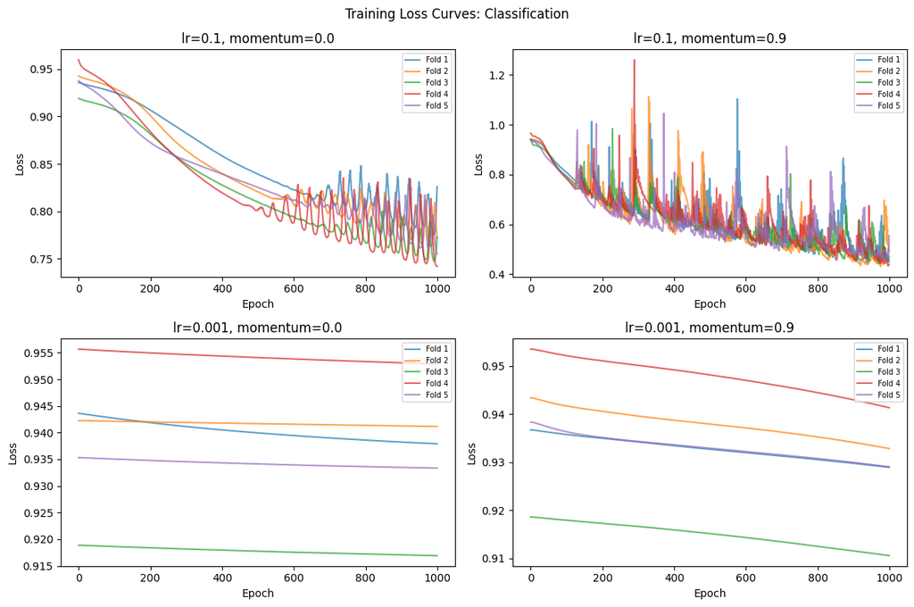

```python
fig, axes = plt.subplots(2, 2, figsize=(12, 8))
fig.suptitle("Training Loss Curves: Classification")

for i, lr in enumerate(lr_values):
    for j, mom in enumerate(mom_values):

        metrics, fold_losses = cv_function(X_train_c, y_train_c, ClassificationNetwork, lr=lr, momentum=mom)

        ax = axes[i][j]
        for k, losses in enumerate(fold_losses):
            ax.plot(losses, alpha=0.7, label=f"Fold {k+1}")
        ax.set_title(f"lr={lr}, momentum={mom}")
        ax.set_xlabel("Epoch")
        ax.set_ylabel("Loss")
        ax.legend(fontsize=7)

        cv_results(metrics, task="classification")
        print(f"  lr={lr}, momentum={mom}\n")

plt.tight_layout()
plt.show()
```

Regression:

```
Mean MSE: nan ± nan
  lr=0.1, momentum=0.0

Mean MSE: 7354.5119 ± 14154.5815
  lr=0.1, momentum=0.9

Mean MSE: 293.3278 ± 54.9582
  lr=0.001, momentum=0.0

Mean MSE: 272.7555 ± 51.8384
  lr=0.001, momentum=0.9
```

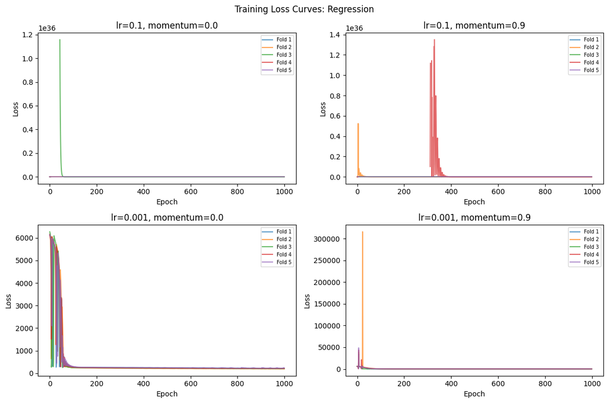

```python
fig, axes = plt.subplots(2, 2, figsize=(12, 8))
fig.suptitle("Training Loss Curves: Regression")

for i, lr in enumerate(lr_values):
    for j, mom in enumerate(mom_values):

        metrics, fold_losses = cv_function(X_train_r, y_train_r, RegressionNetwork, lr=lr, momentum=mom)

        ax = axes[i][j]
        for k, losses in enumerate(fold_losses):
            ax.plot(losses, alpha=0.7, label=f"Fold {k+1}")
        ax.set_title(f"lr={lr}, momentum={mom}")
        ax.set_xlabel("Epoch")
        ax.set_ylabel("Loss")
        ax.legend(fontsize=7)

        cv_results(metrics, task="regression")
        print(f"  lr={lr}, momentum={mom}\n")

plt.tight_layout()
plt.show()
```

### Best Model vs. Default

```python
clf_best = ClassificationNetwork(act1=nn.ReLU(), act2=nn.Tanh())
clf_best.learn(X_train_c, y_train_c, epochs=1000, lr=0.1, momentum=0)
acc, prec, rec = clf_best.evaluate(X_test_c, y_test_c)
print(f"Accuracy: {acc:.4f}, Precision: {prec:.4f}, Recall: {rec:.4f}")
```

```
Accuracy: 0.4444, Precision: 0.3235, Recall: 0.6111
```

Best regression model:

```python
reg_best = RegressionNetwork(act1=nn.ReLU(), act2=nn.Tanh())
reg_best.learn(X_train_r, y_train_r, epochs=1000, lr=0.001, momentum=0.9)
mse = reg_best.evaluate(X_test_r, y_test_r)
print(f"MSE: {mse:.4f}")
```

```
MSE: 226.0764
```

Compare with the default model:

```python
print(f"Acc: {default_acc:.4f}, Prec: {default_prec:.4f}, Rec: {default_rec:.4f}")
print(f"MSE: {default_mse:.4f}")
```

```
Acc: 0.6667, Prec: 0.0000, Rec: 0.0000
MSE: 264.1830
```

The default model predicted entirely class 0, making it useless for prediction. The best model achieves recall = 0.61 and precision = 0.32, representing a meaningful improvement despite lower raw accuracy (0.44 vs 0.67). The accuracy drop is expected since the default model was "accurate" only by predicting the majority class. For regression, there is an improvement in MSE (226.08 vs 264.18), suggesting hyperparameter tuning contributed to better regression performance.